# WWW2016 Twitter Experiments

Doyle, Yurovsky, and Frank

October 17, 2015

This document contains the code for the WWW2016 Twitter experiments.

[output not shown]

## Dataset statistics

```r
d2 <- fread('../data/liwc_wildcards.csv') %>%
  rename(sid=speakerId,rid=replierId,vspeak=verifiedSpeaker,vreply=verifiedReplier) %>%
  na.omit() %>%
  mutate(fratio=(speakerFollowers/(speakerFollowers+replierFollowers))) %>%
  mutate(pa=(ba/(ba+nba)-((ba+bna)/(ba+bna+nba+nbna))))

# Median follower ratio
median(d2$fratio)
```

```
## [1] 0.9009038
```

```r
# Mean tweets per triplet
d2 %>% group_by(sid,rid,category) %>%
  mutate(n=ba+bna+nba+nbna) %>%
  ungroup() %>%
  summarize(mean=mean(n))
```

```
## Source: local data table [1 x 1]
##
##       mean
##      (dbl)
## 1 9.859352
```

```r
# Total distinct dyads
d2 %>% mutate(pid=paste(sid,rid)) %>%
  select(pid) %>%
  distinct() %>%
  summarize(pairs=n())
```

```
##    pairs
## 1: 16570
```

```r
# Total message pairs
d2 %>%
  mutate(pid=paste(sid,rid)) %>%
  mutate(n=ba+bna+nba+nbna) %>%
  select(pid,n) %>%
  group_by(pid) %>%
  summarize(mean=mean(n)) %>%
  ungroup() %>%
  summarize(sum=sum(mean))
```

```
## Source: local data table [1 x 1]
##
##      sum
##    (dbl)
## 1 119640
```

```r
#Total users
d2 %>%
  gather('user','uid',sid,rid) %>%
  select(uid) %>%
  distinct() %>%
  summarize(pairs=n())
```

```
##    pairs
## 1:  2776
```

## Follower-ratio results (Fig. 5,6)

Running inference (slow; run once and then set eval=FALSE). [Note that it is random and there will be slightly different results each time.]

```r
sd <- .5

d2 <- fread('../data/liwc_wildcards.csv') %>%
  rename(sid=speakerId,rid=replierId,vspeak=verifiedSpeaker,vreply=verifiedReplier) %>%
  na.omit() %>%
  mutate(fratio=(speakerFollowers/(speakerFollowers+replierFollowers))>=(100/101)) %>%
  group_by(fratio,rid,category) %>%
  summarise_each(funs(sum), ba, nba, bna, nbna) %>%
  ungroup() %>%
  mutate(pa = log(ba/(ba+nba)) - log(bna/(bna+nbna)))

num_subpops <- length(unique(d2$fratio))
num_markers <- length(unique(d2$category))

alignment_data <- list(NumMarkers=num_markers,
                       NumSubPops = num_subpops,
                       NumObservations = nrow(d2),
                       SpeakerSubPop = as.numeric(d2$fratio)+1,
                       MarkerType = as.numeric(as.factor(d2$category)),
                       NumUtterancesAB = d2$ba+d2$nba,
                       NumUtterancesNotAB = d2$bna+ d2$nbna,
                       CountsAB = d2$ba,
                       CountsNotAB = d2$bna,
                       StdDev = sd)

fit <- stan(file = '../stan/alignment.www2016.stan', data = alignment_data,
            iter = 500, chains =1 )

d3 <- d2
d3$model_eta <- colMeans(rstan:::extract(fit,"eta_ab_observation")$eta_ab_observation)
d3$model_mu <- log(colMeans(rstan:::extract(fit,"mu_ab")$mu_ab))-log(colMeans(rstan:::extract(fit,"mu_notab")$mu_notab))

save(d3,fit,file='../results/www2016_twitter_fratio.RData')
```

Plotting HAM-estimated alignments by marker category with 1 SD intervals. (Not in paper)

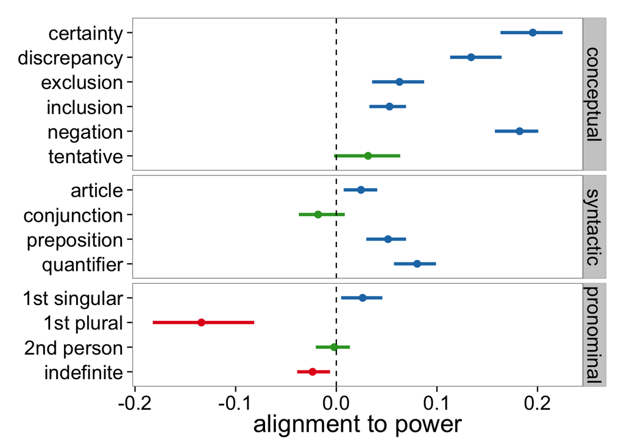

```r
load('../results/www2016_twitter_fratio.RData')

etas <- rstan:::extract(fit,"eta_ab_subpop")$eta_ab_subpop
meandiffs <- colMeans(etas[,2,]-etas[,1,])  #mean difference between the TRUE (powerful) and FALSE (nonpowerful) alignments
ci_upper <- apply(etas[,2,]-etas[,1,],2,'ci_68')
ci_lower <- apply(etas[,2,]-etas[,1,],2,'ci_32')

df <- as.data.frame(list(mean=meandiffs,ci_lower=ci_lower,ci_upper=ci_upper))
df <- convertcategories2(addcategories(df)) %>%
  mutate(color = ifelse(ci_lower<0&ci_upper<0,"less alignment",ifelse(ci_lower>0,"more alignment","n.s."))) %>%
  mutate(color = factor(color,c("more alignment","n.s.","less alignment")))

#pdf(file="results/www2016_ourpowerdiff_fratio_final1sd.pdf",height=6,width=6)
ggplot(aes(y=category,x=mean,color=color),data=df) +
  geom_point(size=3) +
  geom_errorbarh(aes(xmin=ci_lower,xmax=ci_upper,height=0),size=1.25) +
  geom_vline(xintercept=0,lty=2) +
  theme_bw(base_size = 20) +
  theme(panel.grid = element_blank(),axis.title.y= element_blank()) +
  guides(color=FALSE) +
  scale_color_manual(values=c('#1f78b4','#33a02c','#e31a1c')) +
  facet_grid(group~.,space='free',scale='free') +
  labs(y="marker category",x="alignment to power")
```

```r
#dev.off()
```

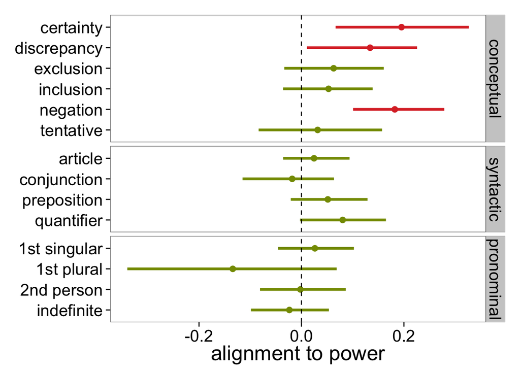

```r
etas <- rstan:::extract(fit,"eta_ab_subpop")$eta_ab_subpop
meandiffs <- colMeans(etas[,2,]-etas[,1,])  #mean difference between the TRUE (powerful) and FALSE (nonpowerful) alignments
ci_upper <- apply(etas[,2,]-etas[,1,],2,'ci_upper')
ci_lower <- apply(etas[,2,]-etas[,1,],2,'ci_lower')

df <- as.data.frame(list(mean=meandiffs,ci_lower=ci_lower,ci_upper=ci_upper))
df <- convertcategories2(addcategories(df)) %>%
  mutate(color = ifelse(ci_lower<0&ci_upper<0,"less alignment",ifelse(ci_lower>0,"more alignment","n.s."))) %>%
  mutate(color = factor(color,c("more alignment","n.s.","less alignment")))

#pdf(file="results/www2016_ourpowerdiff_fratio_final95.pdf",height=6,width=6)
ggplot(aes(y=category,x=mean,color=color),data=df) +
  geom_point(size=3) +
  geom_errorbarh(aes(xmin=ci_lower,xmax=ci_upper,height=0),size=1.25) +
  geom_vline(xintercept=0,lty=2) +
  theme_bw(base_size = 20) +
  theme(panel.grid = element_blank(),axis.title.y= element_blank()) +
  guides(color=FALSE) +
  scale_color_manual(values=c('#dc322f','#859900','#268bd2')) +
  facet_grid(group~.,space='free',scale='free') +
  labs(y="marker category",x="alignment to power")
```

```r
#dev.off()
```

Calculating SCP alignment on follower ratios (Fig. 5; www2016_dnmpowerdiff_fratio_final.pdf)

```r
#Calculating bootstrapped CIs for each category for SCP
df2 <- as.data.frame(d3) %>%
  group_by(fratio,category) %>%
  filter((ba+bna+nba+nbna)>=10) %>%
  mutate(dnm=(ba/(ba+nba))-((ba+bna)/(ba+bna+nba+nbna))) %>%
  multi_boot_standard("dnm", na.rm = T)
df3me <- df2 %>%
  select(fratio,category,mean) %>%
  spread(fratio,mean) %>%
  transmute(category=category,mean = `TRUE` - `FALSE`)
df3mi <- df2 %>%                    #minimum is TRUE lower - FALSE upper
  mutate(min = ifelse(fratio,ci_lower,ci_upper)) %>%
  select(fratio,category,min) %>%
  spread(fratio,min) %>%
  transmute(category=category,min = `TRUE` - `FALSE`)
df3ma <- df2 %>%                    #maximum is TRUE upper - FALSE lower
  mutate(max = ifelse(fratio,ci_upper,ci_lower)) %>%
  select(fratio,category,max) %>%
  spread(fratio,max) %>%
  transmute(category=category,max = `TRUE` - `FALSE`)

df3 <- left_join(df3me,df3mi) %>%
  left_join(df3ma) %>%
  mutate(color = ifelse(min<0&max<0,"less alignment",ifelse(min>0,"more alignment","n.s."))) %>%
  mutate(color = factor(color,c("more alignment","n.s.","less alignment")))
```

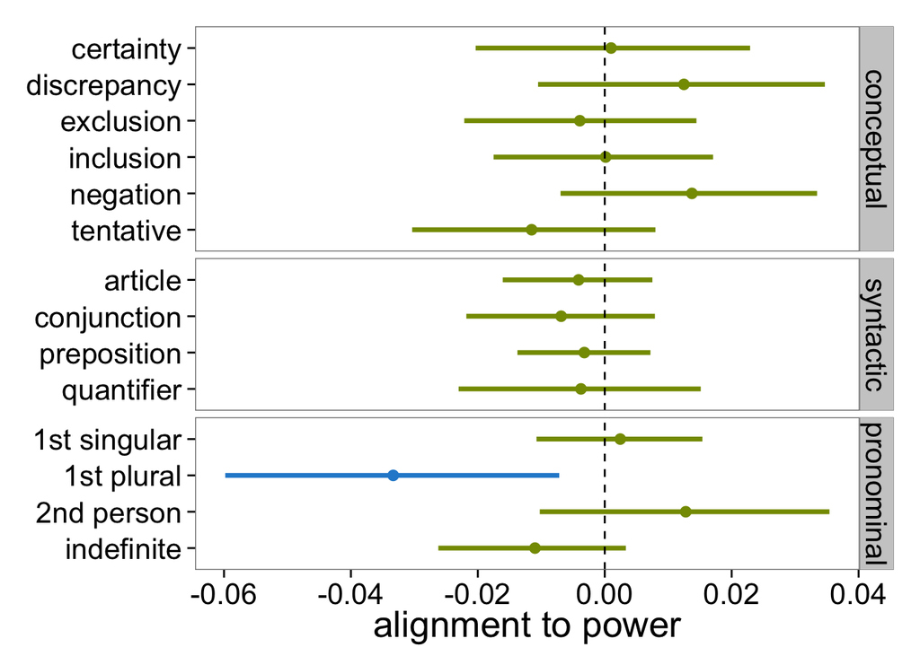

```r
df3 <- convertcategories2(df3)

#pdf(file="../results/www2016_dnmpowerdiff_fratio_final.pdf",height=6,width=6)
ggplot(aes(y=category,x=mean,color=color),data=df3) +
  geom_point(size=3) +
  geom_errorbarh(aes(xmin=min,xmax=max,height=0),size=1.25) +
  geom_vline(xintercept=0,lty=2) +
  theme_bw(base_size = 20) +
  theme(panel.grid = element_blank(),axis.title.y= element_blank()) +
  guides(color=FALSE) +
  scale_color_manual(values=c('#859900','#268bd2')) +
  facet_grid(group~.,space='free',scale='free') +
  labs(y="marker category",x="alignment to power")
```

```r
#dev.off()
```

## Verification status results (Fig. 7,8)

```r
sd <- .5

d2 <- fread('../data/liwc_wildcards.csv') %>%
  rename(sid=speakerId,rid=replierId,vspeak=verifiedSpeaker,vreply=verifiedReplier) %>%
  group_by(vspeak,rid,vreply,category) %>%
  summarise_each(funs(sum), ba, nba, bna, nbna) %>%
  ungroup() %>%
  mutate(pa = log(ba/(ba+nba)) - log(bna/(bna+nbna))) %>%
  filter(vreply == FALSE)

num_subpops <- length(unique(d2$vspeak))
num_markers <- length(unique(d2$category))
#num_repliers <- length(unique(d2$rid))

alignment_data <- list(NumMarkers=num_markers,
                       NumSubPops = num_subpops,
                       NumObservations = nrow(d2),
                       SpeakerSubPop = as.numeric(d2$vspeak)+1,
                       MarkerType = as.numeric(as.factor(d2$category)),
                       NumUtterancesAB = d2$ba+d2$nba,
                       NumUtterancesNotAB = d2$bna+ d2$nbna,
                       CountsAB = d2$ba,
                       CountsNotAB = d2$bna,
                       StdDev = sd)

fit <- stan(file = '../stan/alignment.www2016.stan', data = alignment_data,
            iter = 500, chains =1 )

d3 <- d2
d3$model_eta <- colMeans(rstan:::extract(fit,"eta_ab_observation")$eta_ab_observation)
d3$model_mu <- log(colMeans(rstan:::extract(fit,"mu_ab")$mu_ab))-log(colMeans(rstan:::extract(fit,"mu_notab")$mu_notab))

etas <- rstan:::extract(fit,"eta_ab_subpop")$eta_ab_subpop

save(d3,fit,file='../results/www2016_twitter_verif.RData')
```

Plotting HAM-estimated alignments by marker category with 1 SD intervals. (Not in paper)

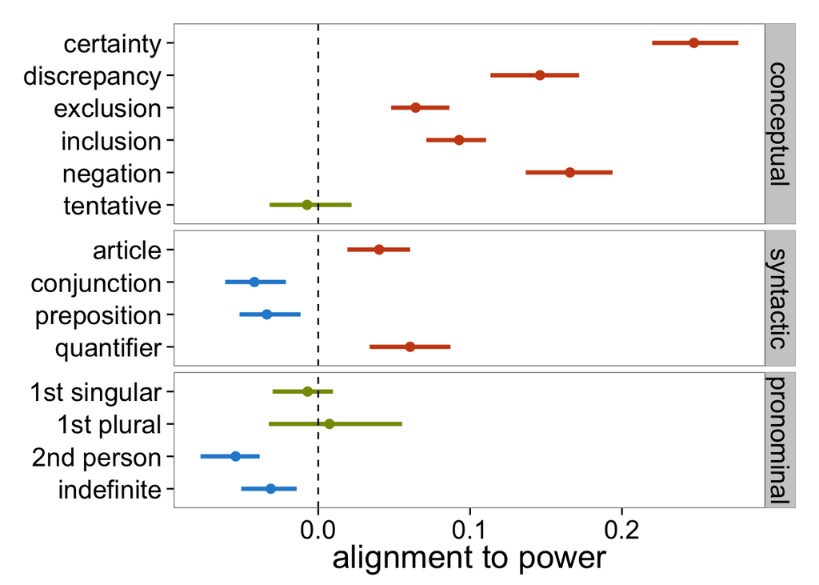

```r
load('../results/www2016_twitter_verif.RData')

#extract the by group eta values
etas <- rstan:::extract(fit,"eta_ab_subpop")$eta_ab_subpop
meandiffs <- colMeans(etas[,2,]-etas[,1,])  #mean difference between the TRUE (powerful) and FALSE (nonpowerful) alignments
ci_upper <- apply(etas[,2,]-etas[,1,],2,'ci_68')
ci_lower <- apply(etas[,2,]-etas[,1,],2,'ci_32')

df <- as.data.frame(list(mean=meandiffs,ci_lower=ci_lower,ci_upper=ci_upper))
df <- convertcategories2(addcategories(df)) %>%
  mutate(color = ifelse(ci_lower<0&ci_upper<0,"less alignment",ifelse(ci_lower>0,"more alignment","n.s."))) %>%
  mutate(color = factor(color,c("more alignment","n.s.","less alignment")))

#pdf(file="results/www2016_ourpowerdiff_verif_final1sd.pdf",height=6,width=6)
ggplot(aes(y=category,x=mean,color=color),data=df) +
  geom_point(size=3) +
  geom_errorbarh(aes(xmin=ci_lower,xmax=ci_upper,height=0),size=1.25) +
  geom_vline(xintercept=0,lty=2) +
  theme_bw(base_size = 20) +
  theme(panel.grid = element_blank(),axis.title.y= element_blank()) +
  guides(color=FALSE) +
  scale_color_solarized() +
#  scale_color_manual(values=c('#dc322f','#859900','#268bd2')) +
  facet_grid(group~.,space='free',scale='free') +
  labs(y="marker category",x="alignment to power")
```

```r
#dev.off()
```

Plotting HAM-estimated alignments by marker category with 95% CIs. (Figure 8 in paper; www2016_ourpowerdiff_verif_final95.pdf)

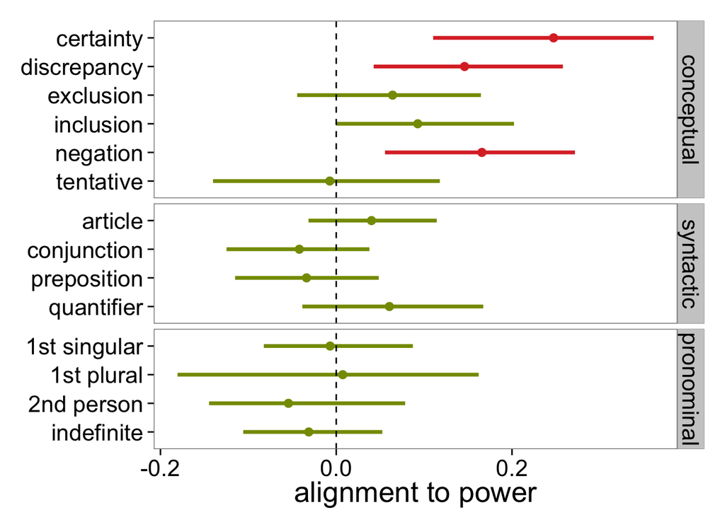

```r
ci_upper <- apply(etas[,2,]-etas[,1,],2,'ci_upper')
ci_lower <- apply(etas[,2,]-etas[,1,],2,'ci_lower')

df <- as.data.frame(list(mean=meandiffs,ci_lower=ci_lower,ci_upper=ci_upper))
df <- convertcategories2(addcategories(df)) %>%
  mutate(color = ifelse(ci_lower<0&ci_upper<0,"less alignment",ifelse(ci_lower>0,"more alignment","n.s."))) %>%
  mutate(color = factor(color,c("more alignment","n.s.","less alignment")))

#pdf(file="../results/www2016_ourpowerdiff_verif_final95.pdf",height=6,width=6)
ggplot(aes(y=category,x=mean,color=color),data=df) +
  geom_point(size=3) +
  geom_errorbarh(aes(xmin=ci_lower,xmax=ci_upper,height=0),size=1.25) +
  geom_vline(xintercept=0,lty=2) +
  theme_bw(base_size = 20) +
  theme(panel.grid = element_blank(),axis.title.y= element_blank()) +
  guides(color=FALSE) +
  #scale_color_solarized() +
  scale_color_manual(values=c('#dc322f','#859900','#268bd2')) +
  facet_grid(group~.,space='free',scale='free') +
  labs(y="marker category",x="alignment to power")
```

```r
#dev.off()
```

```r
#Calculating bootstrapped CIs for each category for DNM (verification status)
df2 <- as.data.frame(d3) %>%
  group_by(vspeak,category) %>%
  filter((ba+bna+nba+nbna)>=10) %>%
  mutate(dnm=(ba/(ba+nba))-((ba+bna)/(ba+bna+nba+nbna))) %>%
  multi_boot_standard("dnm", na.rm = T)
df3me <- df2 %>%
  select(vspeak,category,mean) %>%
  spread(vspeak,mean) %>%
  transmute(category=category,mean = `TRUE` - `FALSE`)
df3mi <- df2 %>%                    #minimum is TRUE lower - FALSE upper
  mutate(min = ifelse(vspeak,ci_lower,ci_upper)) %>%
  select(vspeak,category,min) %>%
  spread(vspeak,min) %>%
  transmute(category=category,min = `TRUE` - `FALSE`)
df3ma <- df2 %>%                    #maximum is TRUE upper - FALSE lower
  mutate(max = ifelse(vspeak,ci_upper,ci_lower)) %>%
  select(vspeak,category,max) %>%
  spread(vspeak,max) %>%
  transmute(category=category,max = `TRUE` - `FALSE`)

df3 <- left_join(df3me,df3mi) %>%
  left_join(df3ma) %>%
  mutate(color = ifelse(min<0&max<0,"less alignment",ifelse(min>0,"more alignment","n.s."))) %>%
  mutate(color = factor(color,c("more alignment","n.s.","less alignment")))
```

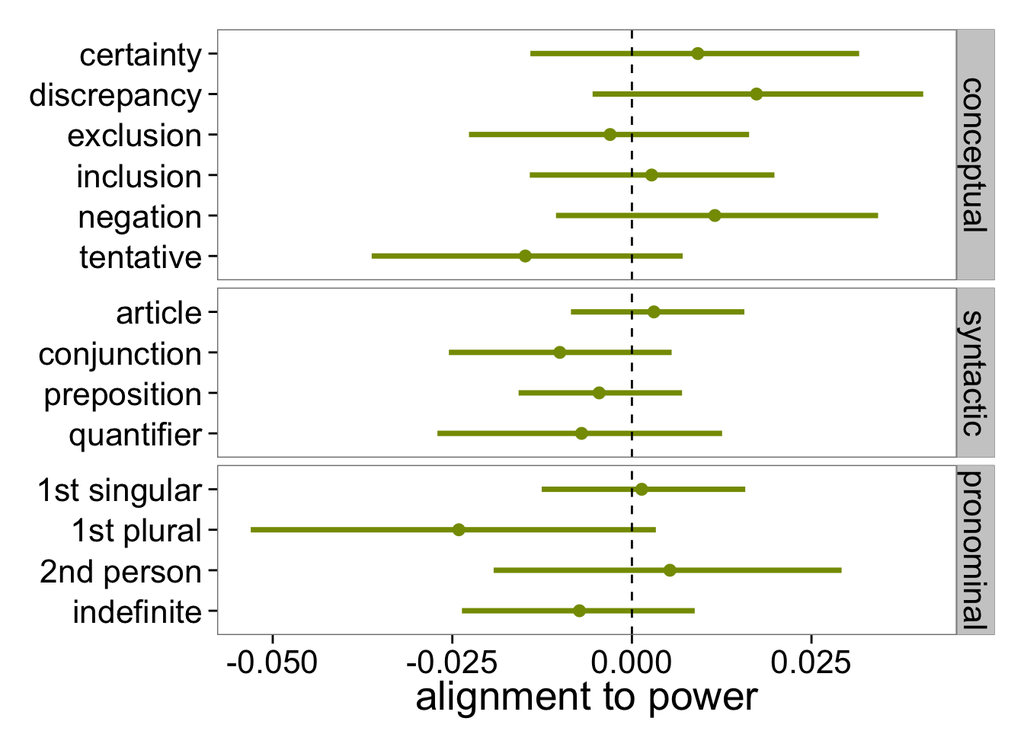

```r
df3 <- convertcategories2(df3)

#pdf(file="results/www2016_dnmpowerdiff_verif_final.pdf",height=6,width=6)
ggplot(aes(y=category,x=mean,color=color),data=df3) +
  geom_point(size=3) +
  geom_errorbarh(aes(xmin=min,xmax=max,height=0),size=1.25) +
  geom_vline(xintercept=0,lty=2) +
  theme_bw(base_size = 20) +
  theme(panel.grid = element_blank(),axis.title.y= element_blank()) +
  guides(color=FALSE) +
  #scale_color_manual(values=c('#dc322f','#859900','#268bd2')) +
  scale_color_manual(values=c('#859900')) +
  facet_grid(group~.,space='free',scale='free') +
  labs(y="marker category",x="alignment to power")
```

```r
#dev.off()
```

## Overall alignment results (Fig. 4)

```r
load('../results/www2016_twitter_verif.RData')

etas2 <- apply(rstan:::extract(fit,"eta_ab_subpop")$eta_ab_subpop,c(1,3),mean)
meandiffs <- apply(etas2,2,'mean')
ci_upper <- apply(etas2,2,'ci_upper')
ci_lower <- apply(etas2,2,'ci_lower')

df <- as.data.frame(list(mean=meandiffs,ci_lower=ci_lower,ci_upper=ci_upper))
df <- convertcategories2(addcategories(df)) %>%
  mutate(color = ifelse(ci_lower<0&ci_upper<0,"less alignment",ifelse(ci_lower>0,"more alignment","n.s."))) %>%
  mutate(color = factor(color,c("more alignment","n.s.","less alignment"))) %>%
  mutate(method='HAM')

df3 <- as.data.frame(d3) %>%
  convertcategories2() %>%
  group_by(category,group) %>%
  filter((ba+bna+nba+nbna)>=10) %>%
  mutate(dnm=(ba/(ba+nba))-((ba+bna)/(ba+bna+nba+nbna))) %>%
  multi_boot_standard("dnm", na.rm = T) %>%
  mutate(method="SCP") %>%
  bind_rows(df)  %>%
  mutate(color = ifelse(ci_lower<0&ci_upper<0,"less alignment",ifelse(ci_lower>0,"more alignment","n.s."))) %>%
  mutate(color = factor(color,c("more alignment","n.s.","less alignment"))) %>%
  mutate(method = factor(method,c("SCP","HAM")))
```

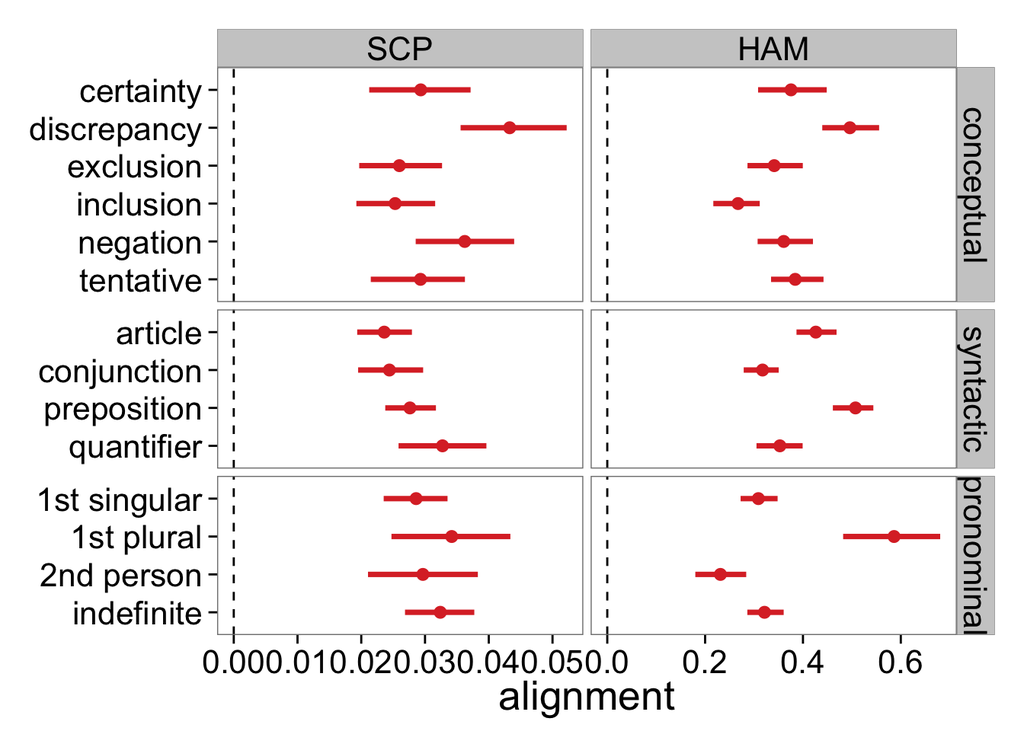

```r
#pdf(file="results/www2016_alignmentdnmour_final95.pdf",height=6,width=8)
ggplot(aes(y=category,x=mean,color=color),data=df3) +
  geom_point(size=3) +
  geom_errorbarh(aes(xmin=ci_lower,xmax=ci_upper,height=0),size=1.25) +
  geom_vline(xintercept=0,lty=2) +
  theme_bw(base_size = 20) +
  theme(panel.grid = element_blank(),axis.title.y= element_blank()) +
  guides(color=FALSE) +
  scale_color_manual(values=c('#dc322f','#859900','#268bd2')) +
  #scale_color_manual(values=c('#859900')) +
  facet_grid(group~method,space='free_y',scale='free') +
  labs(y="marker category",x="alignment")
```

```r
#dev.off()

#correlation between measures
df2 <- as.data.frame(d3) %>%
  convertcategories2() %>%
  group_by(category,group) %>%
  filter((ba+bna+nba+nbna)>=10) %>%
  mutate(dnm=(ba/(ba+nba))-((ba+bna)/(ba+bna+nba+nbna))) %>%
  multi_boot_standard("dnm", na.rm = T) %>%
  rename(scp=mean) %>%
  left_join(df,by='category')
cor(df2$mean,df2$scp)
```

```
## [1] 0.3961813
```